# Homework7

Sam Rosenblatt

10/10/2018

```r
library(tidyverse)
```

## Part 2

Dr. Gotelli: To start simply, assume that the data in each of your treatment groups follow a normal distribution. Specify the sample sizes, means, and variances for each group that would be reasonable if your hypothesis were true.

Sam: My variable of interest will be the percent of a simulated population infected by an SIR epidemic. The control group is the set of simulations where the population was is immunized through random immunization, whereas each treatment group is the set of simulations where the population is immunized(at the same immunization coverage) according to an immunization strategy particular to that treatment group(i.e. the different immunization strategies are the different “treatments”)

To specify the sample sizes , means, and variances I used the below plot to approximate

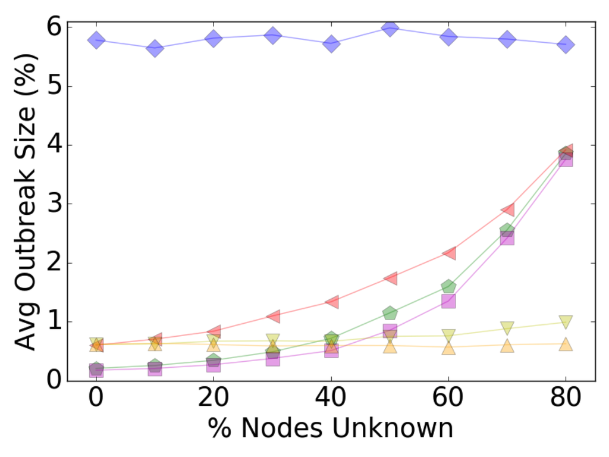

## Part 3

Dr. Gotelli: Using the methods we have covered in class, write code to create a random data set that has these attributes. Organize these data into a data frame or tibble with the appropriate structure.

```r
nGroup <- 7 # number of treatment groups
nName <- c("RandomImmunization","BetweennessImmunization", "DegreeImmunization", "CorenessImmunization", "AcquaintanceKKimmunization", "AcquaintanceKGimmunization", "AcquaintanceGGimmunization" ) # names of groups
nSize <- c(10000,10000,10000, 10000, 10000, 10000, 10000) # number of observations in each group
nMean <- c(0.059,0.017,0.015, 0.05, 0.022, 0.007, 0.005) # mean of each group
nSD <- c(0.04, 0.01,0.01, 0.01, 0.025, 0.02, 0.015) # standard deviation of each group

ID <- 1:(sum(nSize)) # id vector for each row
resVar <- c(rnorm(n=nSize[1],mean=nMean[1],sd=nSD[1]),
            rnorm(n=nSize[2],mean=nMean[2],sd=nSD[2]),
            rnorm(n=nSize[3],mean=nMean[3],sd=nSD[3]),
            rnorm(n=nSize[4],mean=nMean[4],sd=nSD[4]),
            rnorm(n=nSize[5],mean=nMean[5],sd=nSD[5]),
            rnorm(n=nSize[6],mean=nMean[6],sd=nSD[6]),
            rnorm(n=nSize[7],mean=nMean[7],sd=nSD[7]))
TGroup <- rep(nName,nSize)
ANOdata <- data.frame(ID,TGroup,resVar)
str(ANOdata)
```

```
## 'data.frame':    70000 obs. of  3 variables:
##  $ ID    : int  1 2 3 4 5 6 7 8 9 10 ...
##  $ TGroup: Factor w/ 7 levels "AcquaintanceGGimmunization",..: 7 7 7 7 7 7 7 7 7 7 ...
##  $ resVar: num  0.0417 0.148 0.1383 0.0373 0.0911 ...
```

## Part 4

Dr. Gotelli: Now write code to analyze the data (probably as an ANOVA or regression analysis, but possibly as a logistic regression or contingency table analysis.

Sam: We are comparing distributions of continuous variables so we will use ANOVA

```r
ANOmodel <- aov(resVar~TGroup,data=ANOdata)
print(ANOmodel)
```

```
## Call:
##    aov(formula = resVar ~ TGroup, data = ANOdata)
##
## Terms:
##                   TGroup Residuals
## Sum of Squares  26.36133  31.33748
## Deg. of Freedom        6     69993
##
## Residual standard error: 0.02115947
## Estimated effects may be unbalanced
```

```r
print(summary(ANOmodel))
```

```
##                Df Sum Sq Mean Sq F value Pr(>F)
## TGroup          6  26.36   4.394    9813 <2e-16 ***
## Residuals   69993  31.34   0.000
## ---
## Signif. codes:  0 '***' 0.001 '**' 0.01 '*' 0.05 '.' 0.1 ' ' 1
```

```r
z <- summary(ANOmodel)
str(z)
```

```
## List of 1
##  $ :Classes 'anova' and 'data.frame':    2 obs. of  5 variables:
##   ..$ Df     : num [1:2] 6 69993
##   ..$ Sum Sq : num [1:2] 26.4 31.3
##   ..$ Mean Sq: num [1:2] 4.393555 0.000448
##   ..$ F value: num [1:2] 9813 NA
##   ..$ Pr(>F) : num [1:2] 0 NA
##  - attr(*, "class")= chr [1:2] "summary.aov" "listof"
```

```r
aggregate(resVar~TGroup,data=ANOdata,FUN=mean)
```

```
##                       TGroup      resVar
## 1 AcquaintanceGGimmunization 0.005056203
## 2 AcquaintanceKGimmunization 0.007090195
## 3 AcquaintanceKKimmunization 0.022176479
## 4    BetweennessImmunization 0.016972087
## 5       CorenessImmunization 0.050078027
## 6         DegreeImmunization 0.014934516
## 7         RandomImmunization 0.058391450
```

```r
unlist(z)
```

```
##          Df1          Df2      Sum Sq1      Sum Sq2     Mean Sq1
## 6.000000e+00 6.999300e+04 2.636133e+01 3.133748e+01 4.393555e+00
##     Mean Sq2     F value1     F value2      Pr(>F)1      Pr(>F)2
## 4.477231e-04 9.813109e+03           NA 0.000000e+00           NA
```

```r
unlist(z)[7]
```

```
## F value1
## 9813.109
```

```r
ANOsum <- list(Fval=unlist(z)[7],probF=unlist(z)[9])
ANOsum
```

```
## $Fval
## F value1
## 9813.109
##
## $probF
## Pr(>F)1
##       0
```

Write code to generate a useful graph of the data.

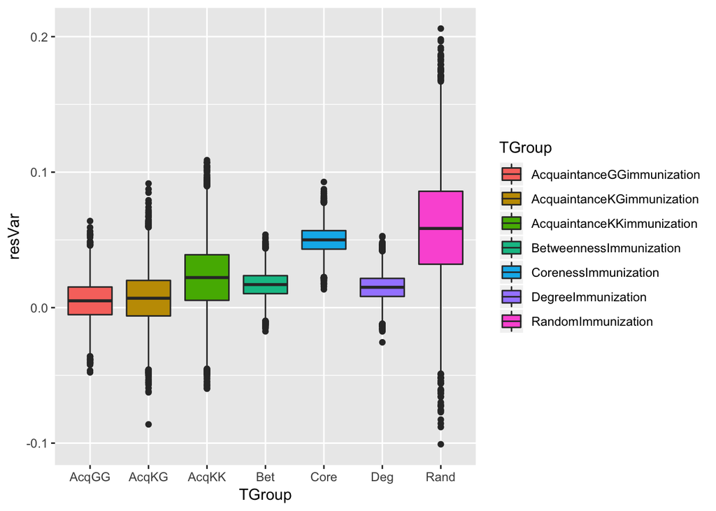

```r
ANOPlot <- ggplot(data=ANOdata,aes(x=TGroup,y=resVar,fill=TGroup)) +
           geom_boxplot()  + scale_x_discrete(labels=c("AcqGG", "AcqKG", "AcqKK", "Bet","Core","Deg","Rand"))
print(ANOPlot)
```

```r
# ggsave(filename="Plot2.pdf",plot=ANOPlot,device="pdf")
#+ theme(text = element_text(size=20), axis.text.x = element_text(angle=90, hjust=1))
```

## Part 5

Try running your analysis multiple times to get a feeling for how variable the results are with the same parameters, but different sets of random numbers.

### Same Parameters Run 2

```r
nGroup <- 7 # number of treatment groups
nName <- c("RandomImmunization","BetweennessImmunization", "DegreeImmunization", "CorenessImmunization", "AcquaintanceKKimmunization", "AcquaintanceKGimmunization", "AcquaintanceGGimmunization" ) # names of groups
nSize <- c(10000,10000,10000, 10000, 10000, 10000, 10000) # number of observations in each group
nMean <- c(0.059,0.017,0.015, 0.05, 0.022, 0.007, 0.005) # mean of each group
nSD <- c(0.04, 0.01,0.01, 0.01, 0.025, 0.02, 0.015) # standard deviation of each group

ID <- 1:(sum(nSize)) # id vector for each row
resVar <- c(rnorm(n=nSize[1],mean=nMean[1],sd=nSD[1]),
            rnorm(n=nSize[2],mean=nMean[2],sd=nSD[2]),
            rnorm(n=nSize[3],mean=nMean[3],sd=nSD[3]),
            rnorm(n=nSize[4],mean=nMean[4],sd=nSD[4]),
            rnorm(n=nSize[5],mean=nMean[5],sd=nSD[5]),
            rnorm(n=nSize[6],mean=nMean[6],sd=nSD[6]),
            rnorm(n=nSize[7],mean=nMean[7],sd=nSD[7]))
TGroup <- rep(nName,nSize)
ANOdata <- data.frame(ID,TGroup,resVar)
str(ANOdata)
```

```
## 'data.frame':    70000 obs. of  3 variables:
##  $ ID    : int  1 2 3 4 5 6 7 8 9 10 ...
##  $ TGroup: Factor w/ 7 levels "AcquaintanceGGimmunization",..: 7 7 7 7 7 7 7 7 7 7 ...
##  $ resVar: num  0.0865 0.0336 0.1582 0.0518 -0.0349 ...
```

```r
ANOmodel <- aov(resVar~TGroup,data=ANOdata)
print(ANOmodel)
```

```
## Call:
##    aov(formula = resVar ~ TGroup, data = ANOdata)
##
## Terms:
##                   TGroup Residuals
## Sum of Squares  26.61442  31.46825
## Deg. of Freedom        6     69993
##
## Residual standard error: 0.02120357
## Estimated effects may be unbalanced
```

```r
print(summary(ANOmodel))
```

```
##                Df Sum Sq Mean Sq F value Pr(>F)
## TGroup          6  26.61   4.436    9866 <2e-16 ***
## Residuals   69993  31.47   0.000
## ---
## Signif. codes:  0 '***' 0.001 '**' 0.01 '*' 0.05 '.' 0.1 ' ' 1
```

```r
z <- summary(ANOmodel)
str(z)
```

```
## List of 1
##  $ :Classes 'anova' and 'data.frame':    2 obs. of  5 variables:
##   ..$ Df     : num [1:2] 6 69993
##   ..$ Sum Sq : num [1:2] 26.6 31.5
##   ..$ Mean Sq: num [1:2] 4.43574 0.00045
##   ..$ F value: num [1:2] 9866 NA
##   ..$ Pr(>F) : num [1:2] 0 NA
##  - attr(*, "class")= chr [1:2] "summary.aov" "listof"
```

```r
aggregate(resVar~TGroup,data=ANOdata,FUN=mean)
```

```
##                       TGroup      resVar
## 1 AcquaintanceGGimmunization 0.004968277
## 2 AcquaintanceKGimmunization 0.007077669
## 3 AcquaintanceKKimmunization 0.022004141
## 4    BetweennessImmunization 0.016929674
## 5       CorenessImmunization 0.050067212
## 6         DegreeImmunization 0.015155425
## 7         RandomImmunization 0.058757613
```

```r
unlist(z)
```

```
##          Df1          Df2      Sum Sq1      Sum Sq2     Mean Sq1
## 6.000000e+00 6.999300e+04 2.661442e+01 3.146825e+01 4.435737e+00
##     Mean Sq2     F value1     F value2      Pr(>F)1      Pr(>F)2
## 4.495914e-04 9.866151e+03           NA 0.000000e+00           NA
```

```r
unlist(z)[7]
```

```
## F value1
## 9866.151
```

```r
ANOsum <- list(Fval=unlist(z)[7],probF=unlist(z)[9])
ANOsum
```

```
## $Fval
## F value1
## 9866.151
##
## $probF
## Pr(>F)1
##       0
```

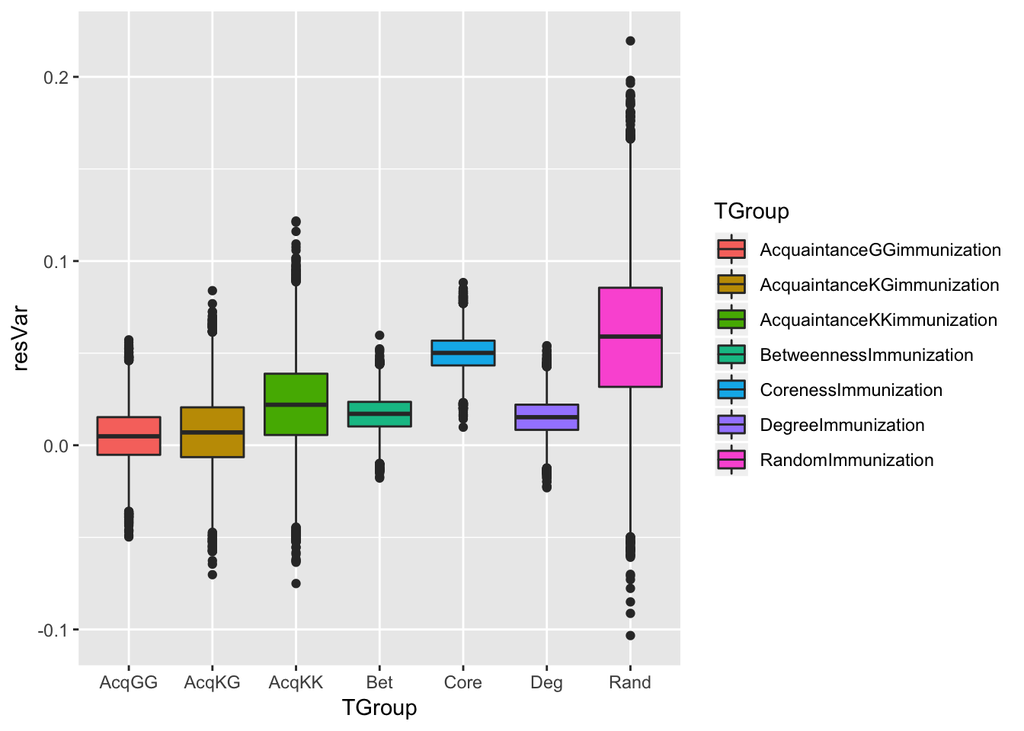

```r
ANOPlot <- ggplot(data=ANOdata,aes(x=TGroup,y=resVar,fill=TGroup)) +
           geom_boxplot()  + scale_x_discrete(labels=c("AcqGG", "AcqKG", "AcqKK", "Bet","Core","Deg","Rand"))
print(ANOPlot)
```

```r
# ggsave(filename="Plot2.pdf",plot=ANOPlot,device="pdf")
#+ theme(text = element_text(size=20), axis.text.x = element_text(angle=90, hjust=1))
```

### Same Parameters Run 3

```
## 'data.frame':    70000 obs. of  3 variables:
##  $ ID    : int  1 2 3 4 5 6 7 8 9 10 ...
##  $ TGroup: Factor w/ 7 levels "AcquaintanceGGimmunization",..: 7 7 7 7 7 7 7 7 7 7 ...
##  $ resVar: num  0.006519 0.045608 -0.000838 0.007637 0.033497 ...
```

```
## Call:
##    aov(formula = resVar ~ TGroup, data = ANOdata)
##
## Terms:
##                   TGroup Residuals
## Sum of Squares  26.80471  31.89022
## Deg. of Freedom        6     69993
##
## Residual standard error: 0.02134526
## Estimated effects may be unbalanced
```

```
##                Df Sum Sq Mean Sq F value Pr(>F)
## TGroup          6  26.80   4.467    9805 <2e-16 ***
## Residuals   69993  31.89   0.000
## ---
## Signif. codes:  0 '***' 0.001 '**' 0.01 '*' 0.05 '.' 0.1 ' ' 1
```

```
## List of 1
##  $ :Classes 'anova' and 'data.frame':    2 obs. of  5 variables:
##   ..$ Df     : num [1:2] 6 69993
##   ..$ Sum Sq : num [1:2] 26.8 31.9
##   ..$ Mean Sq: num [1:2] 4.467452 0.000456
##   ..$ F value: num [1:2] 9805 NA
##   ..$ Pr(>F) : num [1:2] 0 NA
##  - attr(*, "class")= chr [1:2] "summary.aov" "listof"
```

```
##                       TGroup      resVar
## 1 AcquaintanceGGimmunization 0.005000682
## 2 AcquaintanceKGimmunization 0.007091556
## 3 AcquaintanceKKimmunization 0.022149945
## 4    BetweennessImmunization 0.017058870
## 5       CorenessImmunization 0.050088053
## 6         DegreeImmunization 0.014971262
## 7         RandomImmunization 0.059038780
```

```
##          Df1          Df2      Sum Sq1      Sum Sq2     Mean Sq1
## 6.000000e+00 6.999300e+04 2.680471e+01 3.189022e+01 4.467452e+00
##     Mean Sq2     F value1     F value2      Pr(>F)1      Pr(>F)2
## 4.556201e-04 9.805213e+03           NA 0.000000e+00           NA
```

```
## F value1
## 9805.213
```

```
## $Fval
## F value1
## 9805.213
##
## $probF
## Pr(>F)1
##       0
```

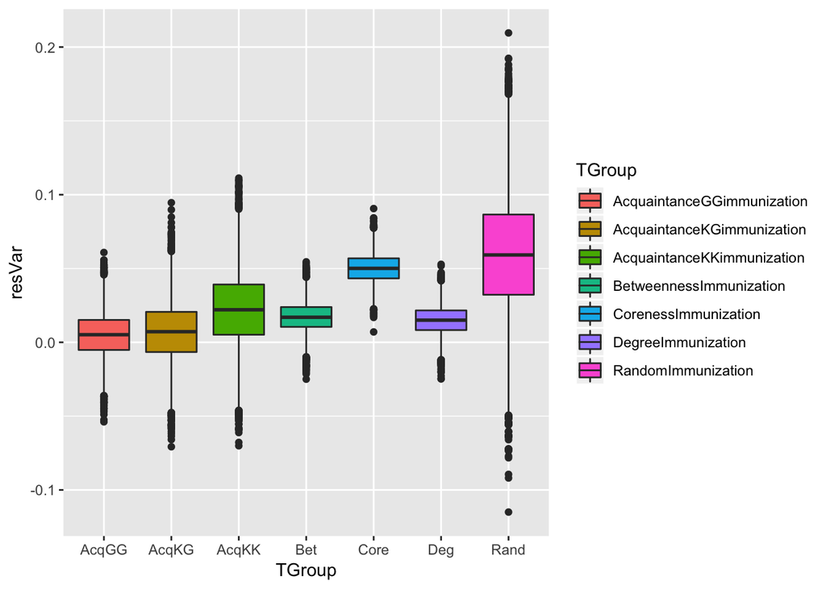

### Same Parameters Run 4

```
## 'data.frame':    70000 obs. of  3 variables:
##  $ ID    : int  1 2 3 4 5 6 7 8 9 10 ...
##  $ TGroup: Factor w/ 7 levels "AcquaintanceGGimmunization",..: 7 7 7 7 7 7 7 7 7 7 ...
##  $ resVar: num  0.0964 0.0427 0.0668 0.055 0.0711 ...
```

```
## Call:
##    aov(formula = resVar ~ TGroup, data = ANOdata)
##
## Terms:
##                   TGroup Residuals
## Sum of Squares  26.64022  31.88879
## Deg. of Freedom        6     69993
##
## Residual standard error: 0.02134478
## Estimated effects may be unbalanced
```

```
##                Df Sum Sq Mean Sq F value Pr(>F)
## TGroup          6  26.64    4.44    9745 <2e-16 ***
## Residuals   69993  31.89    0.00
## ---
## Signif. codes:  0 '***' 0.001 '**' 0.01 '*' 0.05 '.' 0.1 ' ' 1
```

```
## List of 1
##  $ :Classes 'anova' and 'data.frame':    2 obs. of  5 variables:
##   ..$ Df     : num [1:2] 6 69993
##   ..$ Sum Sq : num [1:2] 26.6 31.9
##   ..$ Mean Sq: num [1:2] 4.440036 0.000456
##   ..$ F value: num [1:2] 9745 NA
##   ..$ Pr(>F) : num [1:2] 0 NA
##  - attr(*, "class")= chr [1:2] "summary.aov" "listof"
```

```
##                       TGroup      resVar
## 1 AcquaintanceGGimmunization 0.005058889
## 2 AcquaintanceKGimmunization 0.006737676
## 3 AcquaintanceKKimmunization 0.022073667
## 4    BetweennessImmunization 0.016992962
## 5       CorenessImmunization 0.050186314
## 6         DegreeImmunization 0.014839550
## 7         RandomImmunization 0.058506002
```

```
##          Df1          Df2      Sum Sq1      Sum Sq2     Mean Sq1
## 6.000000e+00 6.999300e+04 2.664022e+01 3.188879e+01 4.440036e+00
##     Mean Sq2     F value1     F value2      Pr(>F)1      Pr(>F)2
## 4.555997e-04 9.745476e+03           NA 0.000000e+00           NA
```

```
## F value1
## 9745.476
```

```
## $Fval
## F value1
## 9745.476
##
## $probF
## Pr(>F)1
##       0
```

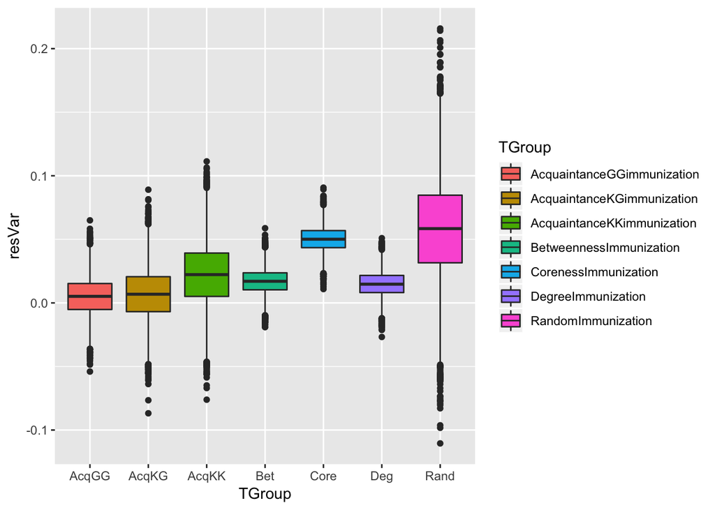

Thoughts: The results are incredibly stable throughout each run using different sets of random numbers. This is likely due to the very large sample size and the large difference in the means between the control and the treatment groups.

## Part 6

Now begin adjusting the means of the different groups. Given the sample sizes you have chosen, how small can the differences between the groups be (the “effect size”) for you to still detect a significant pattern (p < 0.05)?

### Means Adjustment 1: For all treatment groups change the means so that they are approximately only 50% as far from the mean of the control group as they were in the original analysis

```r
nGroup <- 7 # number of treatment groups
nName <- c("RandomImmunization","BetweennessImmunization", "DegreeImmunization", "CorenessImmunization", "AcquaintanceKKimmunization", "AcquaintanceKGimmunization", "AcquaintanceGGimmunization" ) # names of groups
nSize <- c(10000,10000,10000, 10000, 10000, 10000, 10000) # number of observations in each group
nMean <- c(0.059,0.04,0.039, 0.055, 0.042, 0.03, 0.029) # mean of each group
nSD <- c(0.04, 0.01,0.01, 0.01, 0.025, 0.02, 0.015) # standard deviation of each group

ID <- 1:(sum(nSize)) # id vector for each row
resVar <- c(rnorm(n=nSize[1],mean=nMean[1],sd=nSD[1]),
            rnorm(n=nSize[2],mean=nMean[2],sd=nSD[2]),
            rnorm(n=nSize[3],mean=nMean[3],sd=nSD[3]),
            rnorm(n=nSize[4],mean=nMean[4],sd=nSD[4]),
            rnorm(n=nSize[5],mean=nMean[5],sd=nSD[5]),
            rnorm(n=nSize[6],mean=nMean[6],sd=nSD[6]),
            rnorm(n=nSize[7],mean=nMean[7],sd=nSD[7]))
TGroup <- rep(nName,nSize)
ANOdata <- data.frame(ID,TGroup,resVar)
str(ANOdata)
```

```
## 'data.frame':    70000 obs. of  3 variables:
##  $ ID    : int  1 2 3 4 5 6 7 8 9 10 ...
##  $ TGroup: Factor w/ 7 levels "AcquaintanceGGimmunization",..: 7 7 7 7 7 7 7 7 7 7 ...
##  $ resVar: num  0.0538 0.0795 0.1837 0.0748 0.0171 ...
```

```r
ANOmodel <- aov(resVar~TGroup,data=ANOdata)
print(ANOmodel)
```

```
## Call:
##    aov(formula = resVar ~ TGroup, data = ANOdata)
##
## Terms:
##                    TGroup Residuals
## Sum of Squares   7.942464 31.468144
## Deg. of Freedom         6     69993
##
## Residual standard error: 0.02120353
## Estimated effects may be unbalanced
```

```r
print(summary(ANOmodel))
```

```
##                Df Sum Sq Mean Sq F value Pr(>F)
## TGroup          6  7.942  1.3237    2944 <2e-16 ***
## Residuals   69993 31.468  0.0004
## ---
## Signif. codes:  0 '***' 0.001 '**' 0.01 '*' 0.05 '.' 0.1 ' ' 1
```

```r
z <- summary(ANOmodel)
str(z)
```

```
## List of 1
##  $ :Classes 'anova' and 'data.frame':    2 obs. of  5 variables:
##   ..$ Df     : num [1:2] 6 69993
##   ..$ Sum Sq : num [1:2] 7.94 31.47
##   ..$ Mean Sq: num [1:2] 1.32374 0.00045
##   ..$ F value: num [1:2] 2944 NA
##   ..$ Pr(>F) : num [1:2] 0 NA
##  - attr(*, "class")= chr [1:2] "summary.aov" "listof"
```

```r
aggregate(resVar~TGroup,data=ANOdata,FUN=mean)
```

```
##                       TGroup     resVar
## 1 AcquaintanceGGimmunization 0.02923426
## 2 AcquaintanceKGimmunization 0.03030213
## 3 AcquaintanceKKimmunization 0.04217666
## 4    BetweennessImmunization 0.03999103
## 5       CorenessImmunization 0.05490422
## 6         DegreeImmunization 0.03905061
## 7         RandomImmunization 0.05976077
```

```r
unlist(z)
```

```
##          Df1          Df2      Sum Sq1      Sum Sq2     Mean Sq1
## 6.000000e+00 6.999300e+04 7.942464e+00 3.146814e+01 1.323744e+00
##     Mean Sq2     F value1     F value2      Pr(>F)1      Pr(>F)2
## 4.495899e-04 2.944337e+03           NA 0.000000e+00           NA
```

```r
unlist(z)[7]
```

```
## F value1
## 2944.337
```

```r
ANOsum <- list(Fval=unlist(z)[7],probF=unlist(z)[9])
ANOsum
```

```
## $Fval
## F value1
## 2944.337
##
## $probF
## Pr(>F)1
##       0
```

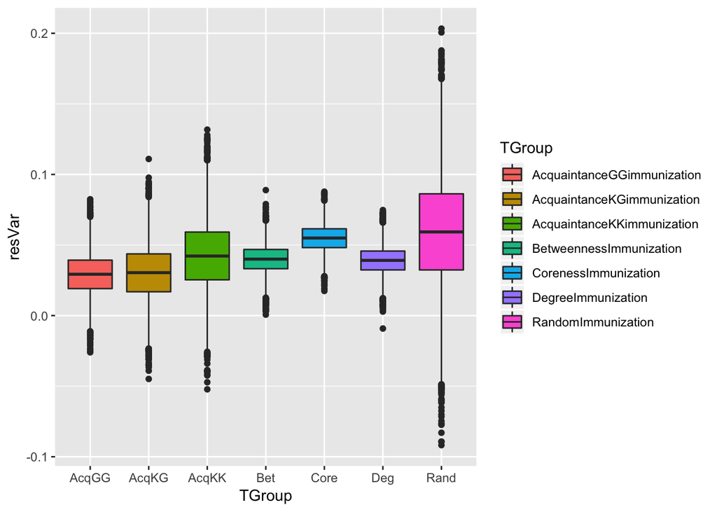

```r
ANOPlot <- ggplot(data=ANOdata,aes(x=TGroup,y=resVar,fill=TGroup)) +
           geom_boxplot()  + scale_x_discrete(labels=c("AcqGG", "AcqKG", "AcqKK", "Bet","Core","Deg","Rand"))
print(ANOPlot)
```

```r
# ggsave(filename="Plot2.pdf",plot=ANOPlot,device="pdf")
#+ theme(text = element_text(size=20), axis.text.x = element_text(angle=90, hjust=1))
```

Result of Means Adjustment 1: p value is still unrealistically low

### Means Adjustment 2: reduce the difference in means by approximately 50% again

```r
nGroup <- 7 # number of treatment groups
nName <- c("RandomImmunization","BetweennessImmunization", "DegreeImmunization", "CorenessImmunization", "AcquaintanceKKimmunization", "AcquaintanceKGimmunization", "AcquaintanceGGimmunization" ) # names of groups
nSize <- c(10000,10000,10000, 10000, 10000, 10000, 10000) # number of observations in each group
nMean <- c(0.059,0.05,0.049, 0.057, 0.053, 0.046, 0.046) # mean of each group
nSD <- c(0.04, 0.01,0.01, 0.01, 0.025, 0.02, 0.015) # standard deviation of each group

ID <- 1:(sum(nSize)) # id vector for each row
resVar <- c(rnorm(n=nSize[1],mean=nMean[1],sd=nSD[1]),
            rnorm(n=nSize[2],mean=nMean[2],sd=nSD[2]),
            rnorm(n=nSize[3],mean=nMean[3],sd=nSD[3]),
            rnorm(n=nSize[4],mean=nMean[4],sd=nSD[4]),
            rnorm(n=nSize[5],mean=nMean[5],sd=nSD[5]),
            rnorm(n=nSize[6],mean=nMean[6],sd=nSD[6]),
            rnorm(n=nSize[7],mean=nMean[7],sd=nSD[7]))
TGroup <- rep(nName,nSize)
ANOdata <- data.frame(ID,TGroup,resVar)
str(ANOdata)
```

```
## 'data.frame':    70000 obs. of  3 variables:
##  $ ID    : int  1 2 3 4 5 6 7 8 9 10 ...
##  $ TGroup: Factor w/ 7 levels "AcquaintanceGGimmunization",..: 7 7 7 7 7 7 7 7 7 7 ...
##  $ resVar: num  0.152988 -0.003289 -0.000314 0.06021 0.059117 ...
```

```r
ANOmodel <- aov(resVar~TGroup,data=ANOdata)
print(ANOmodel)
```

```
## Call:
##    aov(formula = resVar ~ TGroup, data = ANOdata)
##
## Terms:
##                   TGroup Residuals
## Sum of Squares   1.55355  31.63880
## Deg. of Freedom        6     69993
##
## Residual standard error: 0.02126095
## Estimated effects may be unbalanced
```

```r
print(summary(ANOmodel))
```

```
##                Df Sum Sq Mean Sq F value Pr(>F)
## TGroup          6   1.55 0.25892   572.8 <2e-16 ***
## Residuals   69993  31.64 0.00045
## ---
## Signif. codes:  0 '***' 0.001 '**' 0.01 '*' 0.05 '.' 0.1 ' ' 1
```

```r
z <- summary(ANOmodel)
str(z)
```

```
## List of 1
##  $ :Classes 'anova' and 'data.frame':    2 obs. of  5 variables:
##   ..$ Df     : num [1:2] 6 69993
##   ..$ Sum Sq : num [1:2] 1.55 31.64
##   ..$ Mean Sq: num [1:2] 0.258925 0.000452
##   ..$ F value: num [1:2] 573 NA
##   ..$ Pr(>F) : num [1:2] 0 NA
##  - attr(*, "class")= chr [1:2] "summary.aov" "listof"
```

```r
aggregate(resVar~TGroup,data=ANOdata,FUN=mean)
```

```
##                       TGroup     resVar
## 1 AcquaintanceGGimmunization 0.04617103
## 2 AcquaintanceKGimmunization 0.04609038
## 3 AcquaintanceKKimmunization 0.05258575
## 4    BetweennessImmunization 0.05005725
## 5       CorenessImmunization 0.05697245
## 6         DegreeImmunization 0.04904414
## 7         RandomImmunization 0.05914724
```

```r
unlist(z)
```

```
##          Df1          Df2      Sum Sq1      Sum Sq2     Mean Sq1
## 6.000000e+00 6.999300e+04 1.553550e+00 3.163880e+01 2.589249e-01
##     Mean Sq2     F value1     F value2      Pr(>F)1      Pr(>F)2
## 4.520281e-04 5.728072e+02           NA 0.000000e+00           NA
```

```r
unlist(z)[7]
```

```
## F value1
## 572.8072
```

```r
ANOsum <- list(Fval=unlist(z)[7],probF=unlist(z)[9])
ANOsum
```

```
## $Fval
## F value1
## 572.8072
##
## $probF
## Pr(>F)1
##       0
```

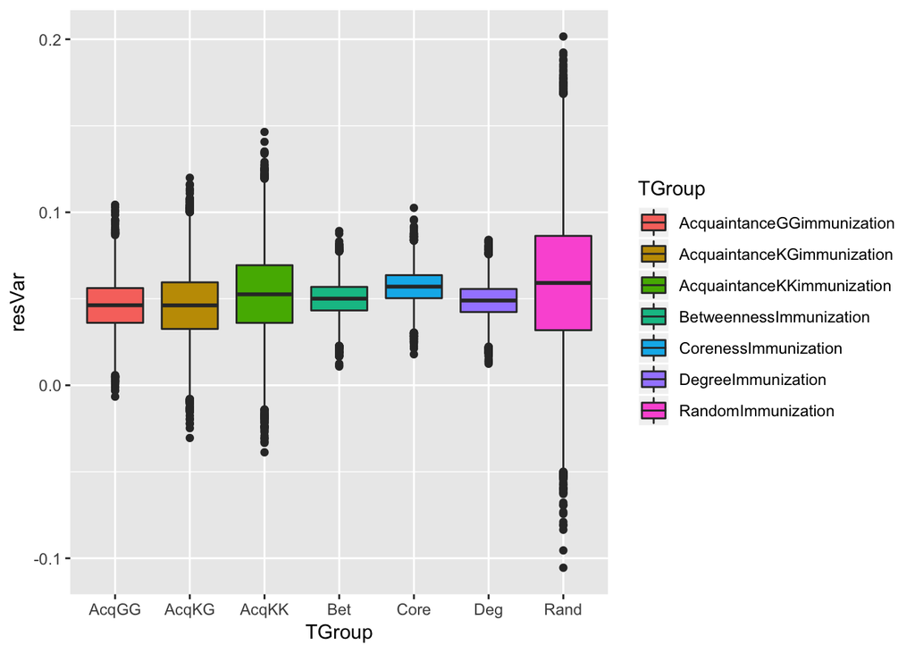

```r
ANOPlot <- ggplot(data=ANOdata,aes(x=TGroup,y=resVar,fill=TGroup)) +
           geom_boxplot()  + scale_x_discrete(labels=c("AcqGG", "AcqKG", "AcqKK", "Bet","Core","Deg","Rand"))
print(ANOPlot)
```

```r
# ggsave(filename="Plot2.pdf",plot=ANOPlot,device="pdf")
#+ theme(text = element_text(size=20), axis.text.x = element_text(angle=90, hjust=1))
```

Result of Means Adjustment 2: p value is still unrealistically low

### Means Adjustment 3: reduce the difference in means by approximately 50% a third time

```r
nGroup <- 7 # number of treatment groups
nName <- c("RandomImmunization","BetweennessImmunization", "DegreeImmunization", "CorenessImmunization", "AcquaintanceKKimmunization", "AcquaintanceKGimmunization", "AcquaintanceGGimmunization" ) # names of groups
nSize <- c(10000,10000,10000, 10000, 10000, 10000, 10000) # number of observations in each group
nMean <- c(0.059,0.0545,0.054, 0.058, 0.056, 0.053, 0.053) # mean of each group
nSD <- c(0.04, 0.01,0.01, 0.01, 0.025, 0.02, 0.015) # standard deviation of each group

ID <- 1:(sum(nSize)) # id vector for each row
resVar <- c(rnorm(n=nSize[1],mean=nMean[1],sd=nSD[1]),
            rnorm(n=nSize[2],mean=nMean[2],sd=nSD[2]),
            rnorm(n=nSize[3],mean=nMean[3],sd=nSD[3]),
            rnorm(n=nSize[4],mean=nMean[4],sd=nSD[4]),
            rnorm(n=nSize[5],mean=nMean[5],sd=nSD[5]),
            rnorm(n=nSize[6],mean=nMean[6],sd=nSD[6]),
            rnorm(n=nSize[7],mean=nMean[7],sd=nSD[7]))
TGroup <- rep(nName,nSize)
ANOdata <- data.frame(ID,TGroup,resVar)
str(ANOdata)
```

```
## 'data.frame':    70000 obs. of  3 variables:
##  $ ID    : int  1 2 3 4 5 6 7 8 9 10 ...
##  $ TGroup: Factor w/ 7 levels "AcquaintanceGGimmunization",..: 7 7 7 7 7 7 7 7 7 7 ...
##  $ resVar: num  0.0227 0.0409 0.0033 0.0523 0.073 ...
```

```r
ANOmodel <- aov(resVar~TGroup,data=ANOdata)
print(ANOmodel)
```

```
## Call:
##    aov(formula = resVar ~ TGroup, data = ANOdata)
##
## Terms:
##                    TGroup Residuals
## Sum of Squares   0.337984 31.560245
## Deg. of Freedom         6     69993
##
## Residual standard error: 0.02123454
## Estimated effects may be unbalanced
```

```r
print(summary(ANOmodel))
```

```
##                Df Sum Sq Mean Sq F value Pr(>F)
## TGroup          6  0.338 0.05633   124.9 <2e-16 ***
## Residuals   69993 31.560 0.00045
## ---
## Signif. codes:  0 '***' 0.001 '**' 0.01 '*' 0.05 '.' 0.1 ' ' 1
```

```r
z <- summary(ANOmodel)
str(z)
```

```
## List of 1
##  $ :Classes 'anova' and 'data.frame':    2 obs. of  5 variables:
##   ..$ Df     : num [1:2] 6 69993
##   ..$ Sum Sq : num [1:2] 0.338 31.56
##   ..$ Mean Sq: num [1:2] 0.056331 0.000451
##   ..$ F value: num [1:2] 125 NA
##   ..$ Pr(>F) : num [1:2] 8.69e-158 NA
##  - attr(*, "class")= chr [1:2] "summary.aov" "listof"
```

```r
aggregate(resVar~TGroup,data=ANOdata,FUN=mean)
```

```
##                       TGroup     resVar
## 1 AcquaintanceGGimmunization 0.05307348
## 2 AcquaintanceKGimmunization 0.05295310
## 3 AcquaintanceKKimmunization 0.05609690
## 4    BetweennessImmunization 0.05461267
## 5       CorenessImmunization 0.05801340
## 6         DegreeImmunization 0.05418968
## 7         RandomImmunization 0.05900570
```

```r
unlist(z)
```

```
##           Df1           Df2       Sum Sq1       Sum Sq2      Mean Sq1
##  6.000000e+00  6.999300e+04  3.379837e-01  3.156025e+01  5.633061e-02
##      Mean Sq2      F value1      F value2       Pr(>F)1       Pr(>F)2
##  4.509057e-04  1.249277e+02            NA 8.685179e-158            NA
```

```r
unlist(z)[7]
```

```
## F value1
## 124.9277
```

```r
ANOsum <- list(Fval=unlist(z)[7],probF=unlist(z)[9])
ANOsum
```

```
## $Fval
## F value1
## 124.9277
##
## $probF
##       Pr(>F)1
## 8.685179e-158
```

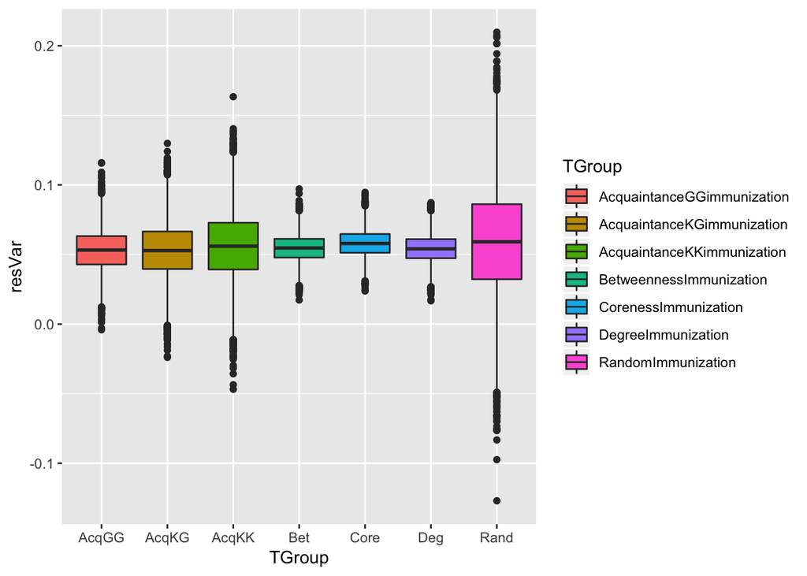

```r
ANOPlot <- ggplot(data=ANOdata,aes(x=TGroup,y=resVar,fill=TGroup)) +
           geom_boxplot()  + scale_x_discrete(labels=c("AcqGG", "AcqKG", "AcqKK", "Bet","Core","Deg","Rand"))
print(ANOPlot)
```

```r
# ggsave(filename="Plot2.pdf",plot=ANOPlot,device="pdf")
#+ theme(text = element_text(size=20), axis.text.x = element_text(angle=90, hjust=1))
```

Result of Means Adjustment 3: Ok well now at least the value is not less than half of machine epsilon. Lets keep going

### Means Adjustment 4: reduce the difference in means by approximately 50% a fourth time

```r
nGroup <- 7 # number of treatment groups
nName <- c("RandomImmunization","BetweennessImmunization", "DegreeImmunization", "CorenessImmunization", "AcquaintanceKKimmunization", "AcquaintanceKGimmunization", "AcquaintanceGGimmunization" ) # names of groups
nSize <- c(10000,10000,10000, 10000, 10000, 10000, 10000) # number of observations in each group
nMean <- c(0.059,0.057,0.0565, 0.0585, 0.058, 0.056, 0.056) # mean of each group
nSD <- c(0.04, 0.01,0.01, 0.01, 0.025, 0.02, 0.015) # standard deviation of each group

ID <- 1:(sum(nSize)) # id vector for each row
resVar <- c(rnorm(n=nSize[1],mean=nMean[1],sd=nSD[1]),
            rnorm(n=nSize[2],mean=nMean[2],sd=nSD[2]),
            rnorm(n=nSize[3],mean=nMean[3],sd=nSD[3]),
            rnorm(n=nSize[4],mean=nMean[4],sd=nSD[4]),
            rnorm(n=nSize[5],mean=nMean[5],sd=nSD[5]),
            rnorm(n=nSize[6],mean=nMean[6],sd=nSD[6]),
            rnorm(n=nSize[7],mean=nMean[7],sd=nSD[7]))
TGroup <- rep(nName,nSize)
ANOdata <- data.frame(ID,TGroup,resVar)
str(ANOdata)
```

```
## 'data.frame':    70000 obs. of  3 variables:
##  $ ID    : int  1 2 3 4 5 6 7 8 9 10 ...
##  $ TGroup: Factor w/ 7 levels "AcquaintanceGGimmunization",..: 7 7 7 7 7 7 7 7 7 7 ...
##  $ resVar: num  0.1154 0.0634 0.0253 0.0861 0.1147 ...
```

```r
ANOmodel <- aov(resVar~TGroup,data=ANOdata)
print(ANOmodel)
```

```
## Call:
##    aov(formula = resVar ~ TGroup, data = ANOdata)
##
## Terms:
##                   TGroup Residuals
## Sum of Squares   0.09415  31.33724
## Deg. of Freedom        6     69993
##
## Residual standard error: 0.02115939
## Estimated effects may be unbalanced
```

```r
print(summary(ANOmodel))
```

```
##                Df Sum Sq  Mean Sq F value Pr(>F)
## TGroup          6  0.094 0.015692   35.05 <2e-16 ***
## Residuals   69993 31.337 0.000448
## ---
## Signif. codes:  0 '***' 0.001 '**' 0.01 '*' 0.05 '.' 0.1 ' ' 1
```

```r
z <- summary(ANOmodel)
str(z)
```

```
## List of 1
##  $ :Classes 'anova' and 'data.frame':    2 obs. of  5 variables:
##   ..$ Df     : num [1:2] 6 69993
##   ..$ Sum Sq : num [1:2] 0.0942 31.3372
##   ..$ Mean Sq: num [1:2] 0.015692 0.000448
##   ..$ F value: num [1:2] 35 NA
##   ..$ Pr(>F) : num [1:2] 1.42e-42 NA
##  - attr(*, "class")= chr [1:2] "summary.aov" "listof"
```

```r
aggregate(resVar~TGroup,data=ANOdata,FUN=mean)
```

```
##                       TGroup     resVar
## 1 AcquaintanceGGimmunization 0.05600072
## 2 AcquaintanceKGimmunization 0.05597036
## 3 AcquaintanceKKimmunization 0.05820581
## 4    BetweennessImmunization 0.05699971
## 5       CorenessImmunization 0.05852185
## 6         DegreeImmunization 0.05649901
## 7         RandomImmunization 0.05900744
```

```r
unlist(z)
```

```
##          Df1          Df2      Sum Sq1      Sum Sq2     Mean Sq1
## 6.000000e+00 6.999300e+04 9.415006e-02 3.133724e+01 1.569168e-02
##     Mean Sq2     F value1     F value2      Pr(>F)1      Pr(>F)2
## 4.477196e-04 3.504800e+01           NA 1.423094e-42           NA
```

```r
unlist(z)[7]
```

```
## F value1
##   35.048
```

```r
ANOsum <- list(Fval=unlist(z)[7],probF=unlist(z)[9])
ANOsum
```

```
## $Fval
## F value1
##   35.048
##
## $probF
##      Pr(>F)1
## 1.423094e-42
```

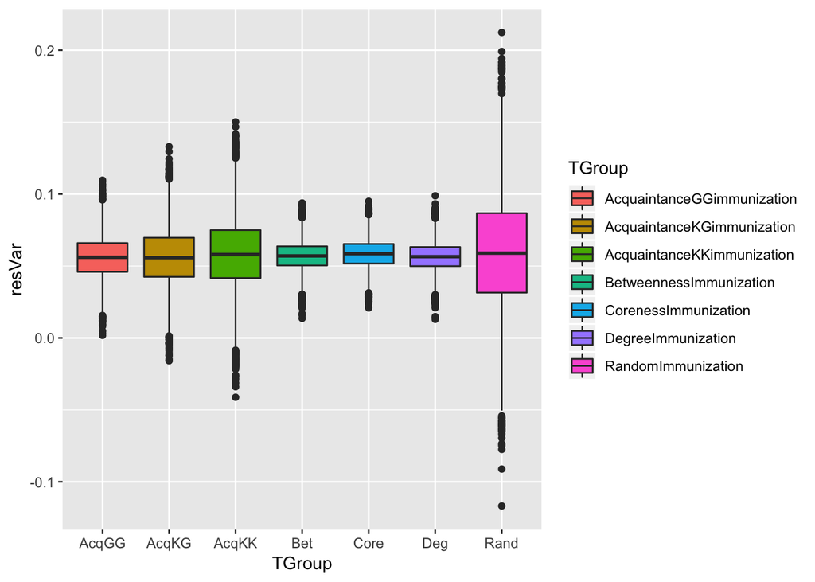

```r
ANOPlot <- ggplot(data=ANOdata,aes(x=TGroup,y=resVar,fill=TGroup)) +
           geom_boxplot()  + scale_x_discrete(labels=c("AcqGG", "AcqKG", "AcqKK", "Bet","Core","Deg","Rand"))
print(ANOPlot)
```

```r
# ggsave(filename="Plot2.pdf",plot=ANOPlot,device="pdf")
#+ theme(text = element_text(size=20), axis.text.x = element_text(angle=90, hjust=1))
```

Result of Means Adjustment 4: Lets keep going until we get p > 0.05

### Means Adjustment 5: reduce the difference in means by approximately 50% a fifth time

```r
nGroup <- 7 # number of treatment groups
nName <- c("RandomImmunization","BetweennessImmunization", "DegreeImmunization", "CorenessImmunization", "AcquaintanceKKimmunization", "AcquaintanceKGimmunization", "AcquaintanceGGimmunization" ) # names of groups
nSize <- c(10000,10000,10000, 10000, 10000, 10000, 10000) # number of observations in each group
nMean <- c(0.059,0.058,0.05725, 0.05875, 0.05875, 0.0575, 0.0575) # mean of each group
nSD <- c(0.04, 0.01,0.01, 0.01, 0.025, 0.02, 0.015) # standard deviation of each group

ID <- 1:(sum(nSize)) # id vector for each row
resVar <- c(rnorm(n=nSize[1],mean=nMean[1],sd=nSD[1]),
            rnorm(n=nSize[2],mean=nMean[2],sd=nSD[2]),
            rnorm(n=nSize[3],mean=nMean[3],sd=nSD[3]),
            rnorm(n=nSize[4],mean=nMean[4],sd=nSD[4]),
            rnorm(n=nSize[5],mean=nMean[5],sd=nSD[5]),
            rnorm(n=nSize[6],mean=nMean[6],sd=nSD[6]),
            rnorm(n=nSize[7],mean=nMean[7],sd=nSD[7]))
TGroup <- rep(nName,nSize)
ANOdata <- data.frame(ID,TGroup,resVar)
str(ANOdata)
```

```
## 'data.frame':    70000 obs. of  3 variables:
##  $ ID    : int  1 2 3 4 5 6 7 8 9 10 ...
##  $ TGroup: Factor w/ 7 levels "AcquaintanceGGimmunization",..: 7 7 7 7 7 7 7 7 7 7 ...
##  $ resVar: num  0.011 0.0817 0.0741 0.0602 0.0637 ...
```

```r
ANOmodel <- aov(resVar~TGroup,data=ANOdata)
print(ANOmodel)
```

```
## Call:
##    aov(formula = resVar ~ TGroup, data = ANOdata)
##
## Terms:
##                    TGroup Residuals
## Sum of Squares   0.033528 31.610838
## Deg. of Freedom         6     69993
##
## Residual standard error: 0.02125155
## Estimated effects may be unbalanced
```

```r
print(summary(ANOmodel))
```

```
##                Df Sum Sq  Mean Sq F value   Pr(>F)
## TGroup          6  0.034 0.005588   12.37 5.61e-14 ***
## Residuals   69993 31.611 0.000452
## ---
## Signif. codes:  0 '***' 0.001 '**' 0.01 '*' 0.05 '.' 0.1 ' ' 1
```

```r
z <- summary(ANOmodel)
str(z)
```

```
## List of 1
##  $ :Classes 'anova' and 'data.frame':    2 obs. of  5 variables:
##   ..$ Df     : num [1:2] 6 69993
##   ..$ Sum Sq : num [1:2] 0.0335 31.6108
##   ..$ Mean Sq: num [1:2] 0.005588 0.000452
##   ..$ F value: num [1:2] 12.4 NA
##   ..$ Pr(>F) : num [1:2] 5.61e-14 NA
##  - attr(*, "class")= chr [1:2] "summary.aov" "listof"
```

```r
aggregate(resVar~TGroup,data=ANOdata,FUN=mean)
```

```
##                       TGroup     resVar
## 1 AcquaintanceGGimmunization 0.05747330
## 2 AcquaintanceKGimmunization 0.05757925
## 3 AcquaintanceKKimmunization 0.05854093
## 4    BetweennessImmunization 0.05793699
## 5       CorenessImmunization 0.05864842
## 6         DegreeImmunization 0.05721704
## 7         RandomImmunization 0.05927795
```

```r
unlist(z)
```

```
##          Df1          Df2      Sum Sq1      Sum Sq2     Mean Sq1
## 6.000000e+00 6.999300e+04 3.352776e-02 3.161084e+01 5.587959e-03
##     Mean Sq2     F value1     F value2      Pr(>F)1      Pr(>F)2
## 4.516286e-04 1.237291e+01           NA 5.607185e-14           NA
```

```r
unlist(z)[7]
```

```
## F value1
## 12.37291
```

```r
ANOsum <- list(Fval=unlist(z)[7],probF=unlist(z)[9])
ANOsum
```

```
## $Fval
## F value1
## 12.37291
##
## $probF
##      Pr(>F)1
## 5.607185e-14
```

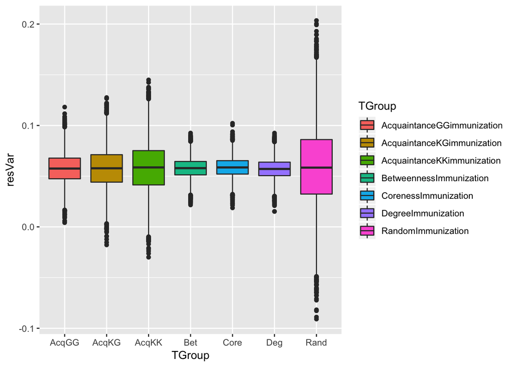

```r
ANOPlot <- ggplot(data=ANOdata,aes(x=TGroup,y=resVar,fill=TGroup)) +
           geom_boxplot()  + scale_x_discrete(labels=c("AcqGG", "AcqKG", "AcqKK", "Bet","Core","Deg","Rand"))
print(ANOPlot)
```

```r
# ggsave(filename="Plot2.pdf",plot=ANOPlot,device="pdf")
#+ theme(text = element_text(size=20), axis.text.x = element_text(angle=90, hjust=1))
```

Result of Means Adjustment 5: Lets keep going until we get p > 0.05

### Means Adjustment 6: reduce the difference in means by approximately 50% a sixth time

```r
nGroup <- 7 # number of treatment groups
nName <- c("RandomImmunization","BetweennessImmunization", "DegreeImmunization", "CorenessImmunization", "AcquaintanceKKimmunization", "AcquaintanceKGimmunization", "AcquaintanceGGimmunization" ) # names of groups
nSize <- c(10000,10000,10000, 10000, 10000, 10000, 10000) # number of observations in each group
nMean <- c(0.059,0.0585,0.058, 0.0589, 0.0589, 0.05825, 0.05825) # mean of each group
nSD <- c(0.04, 0.01,0.01, 0.01, 0.025, 0.02, 0.015) # standard deviation of each group

ID <- 1:(sum(nSize)) # id vector for each row
resVar <- c(rnorm(n=nSize[1],mean=nMean[1],sd=nSD[1]),
            rnorm(n=nSize[2],mean=nMean[2],sd=nSD[2]),
            rnorm(n=nSize[3],mean=nMean[3],sd=nSD[3]),
            rnorm(n=nSize[4],mean=nMean[4],sd=nSD[4]),
            rnorm(n=nSize[5],mean=nMean[5],sd=nSD[5]),
            rnorm(n=nSize[6],mean=nMean[6],sd=nSD[6]),
            rnorm(n=nSize[7],mean=nMean[7],sd=nSD[7]))
TGroup <- rep(nName,nSize)
ANOdata <- data.frame(ID,TGroup,resVar)
str(ANOdata)
```

```
## 'data.frame':    70000 obs. of  3 variables:
##  $ ID    : int  1 2 3 4 5 6 7 8 9 10 ...
##  $ TGroup: Factor w/ 7 levels "AcquaintanceGGimmunization",..: 7 7 7 7 7 7 7 7 7 7 ...
##  $ resVar: num  0.0418 0.0596 0.021 0.0449 0.0846 ...
```

```r
ANOmodel <- aov(resVar~TGroup,data=ANOdata)
print(ANOmodel)
```

```
## Call:
##    aov(formula = resVar ~ TGroup, data = ANOdata)
##
## Terms:
##                    TGroup Residuals
## Sum of Squares   0.016565 31.479634
## Deg. of Freedom         6     69993
##
## Residual standard error: 0.02120741
## Estimated effects may be unbalanced
```

```r
print(summary(ANOmodel))
```

```
##                Df Sum Sq   Mean Sq F value   Pr(>F)
## TGroup          6  0.017 0.0027609   6.139 1.91e-06 ***
## Residuals   69993 31.480 0.0004498
## ---
## Signif. codes:  0 '***' 0.001 '**' 0.01 '*' 0.05 '.' 0.1 ' ' 1
```

```r
z <- summary(ANOmodel)
str(z)
```

```
## List of 1
##  $ :Classes 'anova' and 'data.frame':    2 obs. of  5 variables:
##   ..$ Df     : num [1:2] 6 69993
##   ..$ Sum Sq : num [1:2] 0.0166 31.4796
##   ..$ Mean Sq: num [1:2] 0.00276 0.00045
##   ..$ F value: num [1:2] 6.14 NA
##   ..$ Pr(>F) : num [1:2] 1.91e-06 NA
##  - attr(*, "class")= chr [1:2] "summary.aov" "listof"
```

```r
aggregate(resVar~TGroup,data=ANOdata,FUN=mean)
```

```
##                       TGroup     resVar
## 1 AcquaintanceGGimmunization 0.05818886
## 2 AcquaintanceKGimmunization 0.05834668
## 3 AcquaintanceKKimmunization 0.05946487
## 4    BetweennessImmunization 0.05845796
## 5       CorenessImmunization 0.05868521
## 6         DegreeImmunization 0.05798142
## 7         RandomImmunization 0.05911524
```

```r
unlist(z)
```

```
##          Df1          Df2      Sum Sq1      Sum Sq2     Mean Sq1
## 6.000000e+00 6.999300e+04 1.656529e-02 3.147963e+01 2.760881e-03
##     Mean Sq2     F value1     F value2      Pr(>F)1      Pr(>F)2
## 4.497540e-04 6.138646e+00           NA 1.906246e-06           NA
```

```r
unlist(z)[7]
```

```
## F value1
## 6.138646
```

```r
ANOsum <- list(Fval=unlist(z)[7],probF=unlist(z)[9])
ANOsum
```

```
## $Fval
## F value1
## 6.138646
##
## $probF
##      Pr(>F)1
## 1.906246e-06
```

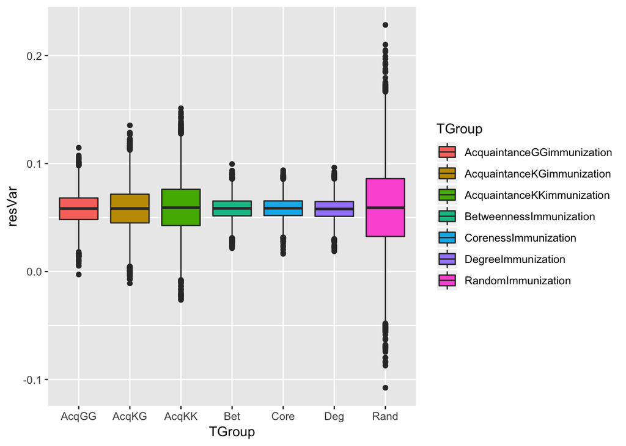

```r
ANOPlot <- ggplot(data=ANOdata,aes(x=TGroup,y=resVar,fill=TGroup)) +
           geom_boxplot()  + scale_x_discrete(labels=c("AcqGG", "AcqKG", "AcqKK", "Bet","Core","Deg","Rand"))
print(ANOPlot)
```

```r
# ggsave(filename="Plot2.pdf",plot=ANOPlot,device="pdf")
#+ theme(text = element_text(size=20), axis.text.x = element_text(angle=90, hjust=1))
```

Result of Means Adjustment 6: Almost there!

### Means Adjustment 7: reduce the difference in means by approximately 50% a seventh time

```r
nGroup <- 7 # number of treatment groups
nName <- c("RandomImmunization","BetweennessImmunization", "DegreeImmunization", "CorenessImmunization", "AcquaintanceKKimmunization", "AcquaintanceKGimmunization", "AcquaintanceGGimmunization" ) # names of groups
nSize <- c(10000,10000,10000, 10000, 10000, 10000, 10000) # number of observations in each group
nMean <- c(0.059,0.05875,0.0585, 0.05895, 0.05895, 0.0588, 0.0588) # mean of each group
nSD <- c(0.04, 0.01,0.01, 0.01, 0.025, 0.02, 0.015) # standard deviation of each group

ID <- 1:(sum(nSize)) # id vector for each row
resVar <- c(rnorm(n=nSize[1],mean=nMean[1],sd=nSD[1]),
            rnorm(n=nSize[2],mean=nMean[2],sd=nSD[2]),
            rnorm(n=nSize[3],mean=nMean[3],sd=nSD[3]),
            rnorm(n=nSize[4],mean=nMean[4],sd=nSD[4]),
            rnorm(n=nSize[5],mean=nMean[5],sd=nSD[5]),
            rnorm(n=nSize[6],mean=nMean[6],sd=nSD[6]),
            rnorm(n=nSize[7],mean=nMean[7],sd=nSD[7]))
TGroup <- rep(nName,nSize)
ANOdata <- data.frame(ID,TGroup,resVar)
str(ANOdata)
```

```
## 'data.frame':    70000 obs. of  3 variables:
##  $ ID    : int  1 2 3 4 5 6 7 8 9 10 ...
##  $ TGroup: Factor w/ 7 levels "AcquaintanceGGimmunization",..: 7 7 7 7 7 7 7 7 7 7 ...
##  $ resVar: num  0.0342 0.087 0.0938 0.0062 0.0708 ...
```

```r
ANOmodel <- aov(resVar~TGroup,data=ANOdata)
print(ANOmodel)
```

```
## Call:
##    aov(formula = resVar ~ TGroup, data = ANOdata)
##
## Terms:
##                    TGroup Residuals
## Sum of Squares   0.002154 31.569104
## Deg. of Freedom         6     69993
##
## Residual standard error: 0.02123752
## Estimated effects may be unbalanced
```

```r
print(summary(ANOmodel))
```

```
##                Df Sum Sq   Mean Sq F value Pr(>F)
## TGroup          6  0.002 0.0003591   0.796  0.573
## Residuals   69993 31.569 0.0004510
```

```r
z <- summary(ANOmodel)
str(z)
```

```
## List of 1
##  $ :Classes 'anova' and 'data.frame':    2 obs. of  5 variables:
##   ..$ Df     : num [1:2] 6 69993
##   ..$ Sum Sq : num [1:2] 0.00215 31.5691
##   ..$ Mean Sq: num [1:2] 0.000359 0.000451
##   ..$ F value: num [1:2] 0.796 NA
##   ..$ Pr(>F) : num [1:2] 0.573 NA
##  - attr(*, "class")= chr [1:2] "summary.aov" "listof"
```

```r
aggregate(resVar~TGroup,data=ANOdata,FUN=mean)
```

```
##                       TGroup     resVar
## 1 AcquaintanceGGimmunization 0.05902710
## 2 AcquaintanceKGimmunization 0.05881637
## 3 AcquaintanceKKimmunization 0.05898416
## 4    BetweennessImmunization 0.05864854
## 5       CorenessImmunization 0.05904030
## 6         DegreeImmunization 0.05856871
## 7         RandomImmunization 0.05895036
```

```r
unlist(z)
```

```
##          Df1          Df2      Sum Sq1      Sum Sq2     Mean Sq1
## 6.000000e+00 6.999300e+04 2.154419e-03 3.156910e+01 3.590699e-04
##     Mean Sq2     F value1     F value2      Pr(>F)1      Pr(>F)2
## 4.510323e-04 7.961068e-01           NA 5.727667e-01           NA
```

```r
unlist(z)[7]
```

```
##  F value1
## 0.7961068
```

```r
ANOsum <- list(Fval=unlist(z)[7],probF=unlist(z)[9])
ANOsum
```

```
## $Fval
##  F value1
## 0.7961068
##
## $probF
##   Pr(>F)1
## 0.5727667
```

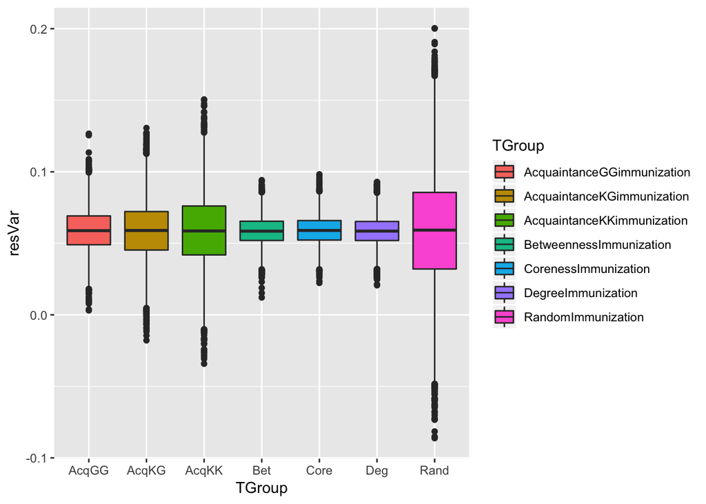

```r
ANOPlot <- ggplot(data=ANOdata,aes(x=TGroup,y=resVar,fill=TGroup)) +
           geom_boxplot()  + scale_x_discrete(labels=c("AcqGG", "AcqKG", "AcqKK", "Bet","Core","Deg","Rand"))
print(ANOPlot)
```

```r
# ggsave(filename="Plot2.pdf",plot=ANOPlot,device="pdf")
#+ theme(text = element_text(size=20), axis.text.x = element_text(angle=90, hjust=1))
```

## Part 7

Alternatively, for the effect sizes you originally hypothesized, what is the minimum sample size you would need in order to detect a statistically significant effect? Again, run the model a few times with the same parameter set to get a feeling for the effect of random variation in the data

### Cut 1: N = (1/2)N_original, Run 1

```r
nGroup <- 7 # number of treatment groups
nName <- c("RandomImmunization","BetweennessImmunization", "DegreeImmunization", "CorenessImmunization", "AcquaintanceKKimmunization", "AcquaintanceKGimmunization", "AcquaintanceGGimmunization" ) # names of groups
N <- 5000
nSize <- c(N,N,N, N, N, N, N) # number of observations in each group
nMean <- c(0.059,0.017,0.015, 0.05, 0.022, 0.007, 0.005) # mean of each group
nSD <- c(0.04, 0.01,0.01, 0.01, 0.025, 0.02, 0.015) # standard deviation of each group

ID <- 1:(sum(nSize)) # id vector for each row
resVar <- c(rnorm(n=nSize[1],mean=nMean[1],sd=nSD[1]),
            rnorm(n=nSize[2],mean=nMean[2],sd=nSD[2]),
            rnorm(n=nSize[3],mean=nMean[3],sd=nSD[3]),
            rnorm(n=nSize[4],mean=nMean[4],sd=nSD[4]),
            rnorm(n=nSize[5],mean=nMean[5],sd=nSD[5]),
            rnorm(n=nSize[6],mean=nMean[6],sd=nSD[6]),
            rnorm(n=nSize[7],mean=nMean[7],sd=nSD[7]))
TGroup <- rep(nName,nSize)
ANOdata <- data.frame(ID,TGroup,resVar)
str(ANOdata)
```

```
## 'data.frame':    35000 obs. of  3 variables:
##  $ ID    : int  1 2 3 4 5 6 7 8 9 10 ...
##  $ TGroup: Factor w/ 7 levels "AcquaintanceGGimmunization",..: 7 7 7 7 7 7 7 7 7 7 ...
##  $ resVar: num  0.00913 0.06266 -0.0051 0.09762 0.12385 ...
```

```r
ANOmodel <- aov(resVar~TGroup,data=ANOdata)
print(ANOmodel)
```

```
## Call:
##    aov(formula = resVar ~ TGroup, data = ANOdata)
##
## Terms:
##                   TGroup Residuals
## Sum of Squares  13.45571  15.86310
## Deg. of Freedom        6     34993
##
## Residual standard error: 0.02129136
## Estimated effects may be unbalanced
```

```r
print(summary(ANOmodel))
```

```
##                Df Sum Sq Mean Sq F value Pr(>F)
## TGroup          6  13.46  2.2426    4947 <2e-16 ***
## Residuals   34993  15.86  0.0005
## ---
## Signif. codes:  0 '***' 0.001 '**' 0.01 '*' 0.05 '.' 0.1 ' ' 1
```

```r
z <- summary(ANOmodel)
str(z)
```

```
## List of 1
##  $ :Classes 'anova' and 'data.frame':    2 obs. of  5 variables:
##   ..$ Df     : num [1:2] 6 34993
##   ..$ Sum Sq : num [1:2] 13.5 15.9
##   ..$ Mean Sq: num [1:2] 2.242618 0.000453
##   ..$ F value: num [1:2] 4947 NA
##   ..$ Pr(>F) : num [1:2] 0 NA
##  - attr(*, "class")= chr [1:2] "summary.aov" "listof"
```

```r
aggregate(resVar~TGroup,data=ANOdata,FUN=mean)
```

```
##                       TGroup      resVar
## 1 AcquaintanceGGimmunization 0.004733746
## 2 AcquaintanceKGimmunization 0.007040940
## 3 AcquaintanceKKimmunization 0.022108672
## 4    BetweennessImmunization 0.016827198
## 5       CorenessImmunization 0.049923046
## 6         DegreeImmunization 0.014989607
## 7         RandomImmunization 0.059079104
```

```r
unlist(z)
```

```
##          Df1          Df2      Sum Sq1      Sum Sq2     Mean Sq1
## 6.000000e+00 3.499300e+04 1.345571e+01 1.586310e+01 2.242618e+00
##     Mean Sq2     F value1     F value2      Pr(>F)1      Pr(>F)2
## 4.533220e-04 4.947076e+03           NA 0.000000e+00           NA
```

```r
unlist(z)[7]
```

```
## F value1
## 4947.076
```

```r
ANOsum <- list(Fval=unlist(z)[7],probF=unlist(z)[9])
ANOsum
```

```
## $Fval
## F value1
## 4947.076
##
## $probF
## Pr(>F)1
##       0
```

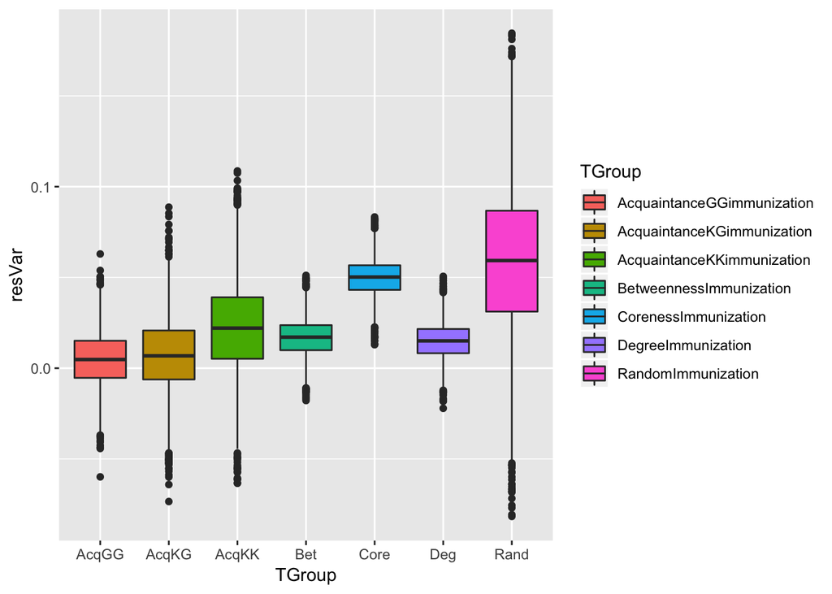

```r
ANOPlot <- ggplot(data=ANOdata,aes(x=TGroup,y=resVar,fill=TGroup)) +
           geom_boxplot()  + scale_x_discrete(labels=c("AcqGG", "AcqKG", "AcqKK", "Bet","Core","Deg","Rand"))
print(ANOPlot)
```

```r
# ggsave(filename="Plot2.pdf",plot=ANOPlot,device="pdf")
#+ theme(text = element_text(size=20), axis.text.x = element_text(angle=90, hjust=1))
```

### Cut N = (1/2)N_original, Run 2

```r
nGroup <- 7 # number of treatment groups
nName <- c("RandomImmunization","BetweennessImmunization", "DegreeImmunization", "CorenessImmunization", "AcquaintanceKKimmunization", "AcquaintanceKGimmunization", "AcquaintanceGGimmunization" ) # names of groups
N <- 5000
nSize <- c(N,N,N, N, N, N, N) # number of observations in each group
nMean <- c(0.059,0.017,0.015, 0.05, 0.022, 0.007, 0.005) # mean of each group
nSD <- c(0.04, 0.01,0.01, 0.01, 0.025, 0.02, 0.015) # standard deviation of each group

ID <- 1:(sum(nSize)) # id vector for each row
resVar <- c(rnorm(n=nSize[1],mean=nMean[1],sd=nSD[1]),
            rnorm(n=nSize[2],mean=nMean[2],sd=nSD[2]),
            rnorm(n=nSize[3],mean=nMean[3],sd=nSD[3]),
            rnorm(n=nSize[4],mean=nMean[4],sd=nSD[4]),
            rnorm(n=nSize[5],mean=nMean[5],sd=nSD[5]),
            rnorm(n=nSize[6],mean=nMean[6],sd=nSD[6]),
            rnorm(n=nSize[7],mean=nMean[7],sd=nSD[7]))
TGroup <- rep(nName,nSize)
ANOdata <- data.frame(ID,TGroup,resVar)
str(ANOdata)
```

```
## 'data.frame':    35000 obs. of  3 variables:
##  $ ID    : int  1 2 3 4 5 6 7 8 9 10 ...
##  $ TGroup: Factor w/ 7 levels "AcquaintanceGGimmunization",..: 7 7 7 7 7 7 7 7 7 7 ...
##  $ resVar: num  0.0369 0.0619 0.0188 0.014 0.0766 ...
```

```r
ANOmodel <- aov(resVar~TGroup,data=ANOdata)
print(ANOmodel)
```

```
## Call:
##    aov(formula = resVar ~ TGroup, data = ANOdata)
##
## Terms:
##                   TGroup Residuals
## Sum of Squares  13.52581  15.89761
## Deg. of Freedom        6     34993
##
## Residual standard error: 0.02131451
## Estimated effects may be unbalanced
```

```r
print(summary(ANOmodel))
```

```
##                Df Sum Sq Mean Sq F value Pr(>F)
## TGroup          6  13.53  2.2543    4962 <2e-16 ***
## Residuals   34993  15.90  0.0005
## ---
## Signif. codes:  0 '***' 0.001 '**' 0.01 '*' 0.05 '.' 0.1 ' ' 1
```

```r
z <- summary(ANOmodel)
str(z)
```

```
## List of 1
##  $ :Classes 'anova' and 'data.frame':    2 obs. of  5 variables:
##   ..$ Df     : num [1:2] 6 34993
##   ..$ Sum Sq : num [1:2] 13.5 15.9
##   ..$ Mean Sq: num [1:2] 2.254302 0.000454
##   ..$ F value: num [1:2] 4962 NA
##   ..$ Pr(>F) : num [1:2] 0 NA
##  - attr(*, "class")= chr [1:2] "summary.aov" "listof"
```

```r
aggregate(resVar~TGroup,data=ANOdata,FUN=mean)
```

```
##                       TGroup      resVar
## 1 AcquaintanceGGimmunization 0.004954238
## 2 AcquaintanceKGimmunization 0.007427324
## 3 AcquaintanceKKimmunization 0.022141873
## 4    BetweennessImmunization 0.017107397
## 5       CorenessImmunization 0.050079610
## 6         DegreeImmunization 0.014926390
## 7         RandomImmunization 0.059551497
```

```r
unlist(z)
```

```
##          Df1          Df2      Sum Sq1      Sum Sq2     Mean Sq1
## 6.000000e+00 3.499300e+04 1.352581e+01 1.589761e+01 2.254302e+00
##     Mean Sq2     F value1     F value2      Pr(>F)1      Pr(>F)2
## 4.543082e-04 4.962054e+03           NA 0.000000e+00           NA
```

```r
unlist(z)[7]
```

```
## F value1
## 4962.054
```

```r
ANOsum <- list(Fval=unlist(z)[7],probF=unlist(z)[9])
ANOsum
```

```
## $Fval
## F value1
## 4962.054
##
## $probF
## Pr(>F)1
##       0
```

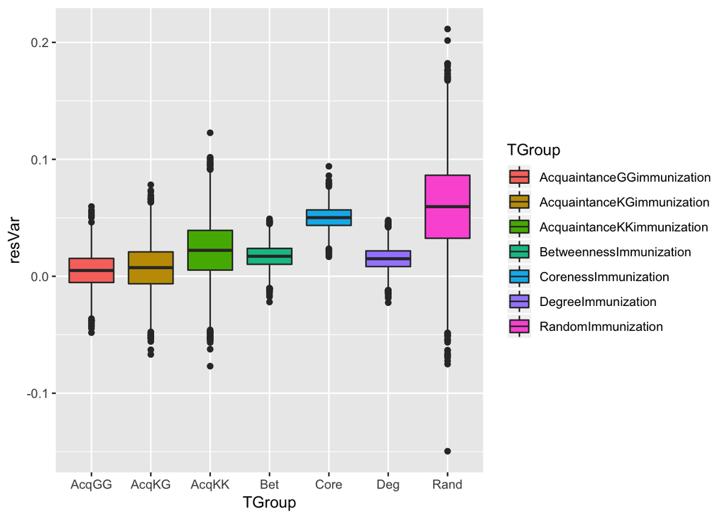

```r
ANOPlot <- ggplot(data=ANOdata,aes(x=TGroup,y=resVar,fill=TGroup)) +
           geom_boxplot()  + scale_x_discrete(labels=c("AcqGG", "AcqKG", "AcqKK", "Bet","Core","Deg","Rand"))
print(ANOPlot)
```

```r
# ggsave(filename="Plot2.pdf",plot=ANOPlot,device="pdf")
#+ theme(text = element_text(size=20), axis.text.x = element_text(angle=90, hjust=1))
```

### Cut 1: N = (1/2)N_original, Run 3

```r
nGroup <- 7 # number of treatment groups
nName <- c("RandomImmunization","BetweennessImmunization", "DegreeImmunization", "CorenessImmunization", "AcquaintanceKKimmunization", "AcquaintanceKGimmunization", "AcquaintanceGGimmunization" ) # names of groups
N <- 5000
nSize <- c(N,N,N, N, N, N, N) # number of observations in each group
nSD <- c(0.04, 0.01,0.01, 0.01, 0.025, 0.02, 0.015) # standard deviation of each group

ID <- 1:(sum(nSize)) # id vector for each row
resVar <- c(rnorm(n=nSize[1],mean=nMean[1],sd=nSD[1]),
            rnorm(n=nSize[2],mean=nMean[2],sd=nSD[2]),
            rnorm(n=nSize[3],mean=nMean[3],sd=nSD[3]),
            rnorm(n=nSize[4],mean=nMean[4],sd=nSD[4]),
            rnorm(n=nSize[5],mean=nMean[5],sd=nSD[5]),
            rnorm(n=nSize[6],mean=nMean[6],sd=nSD[6]),
            rnorm(n=nSize[7],mean=nMean[7],sd=nSD[7]))
TGroup <- rep(nName,nSize)
ANOdata <- data.frame(ID,TGroup,resVar)
str(ANOdata)
```

```
## 'data.frame':    35000 obs. of  3 variables:
##  $ ID    : int  1 2 3 4 5 6 7 8 9 10 ...
##  $ TGroup: Factor w/ 7 levels "AcquaintanceGGimmunization",..: 7 7 7 7 7 7 7 7 7 7 ...
##  $ resVar: num  0.139 0.0613 0.0949 0.0413 0.0435 ...
```

```r
ANOmodel <- aov(resVar~TGroup,data=ANOdata)
print(ANOmodel)
```

```
## Call:
##    aov(formula = resVar ~ TGroup, data = ANOdata)
##
## Terms:
##                   TGroup Residuals
## Sum of Squares  13.50211  15.80018
## Deg. of Freedom        6     34993
##
## Residual standard error: 0.02124909
## Estimated effects may be unbalanced
```

```r
print(summary(ANOmodel))
```

```
##                Df Sum Sq Mean Sq F value Pr(>F)
## TGroup          6   13.5  2.2504    4984 <2e-16 ***
## Residuals   34993   15.8  0.0005
## ---
## Signif. codes:  0 '***' 0.001 '**' 0.01 '*' 0.05 '.' 0.1 ' ' 1
```

```r
z <- summary(ANOmodel)
str(z)
```

```
## List of 1
##  $ :Classes 'anova' and 'data.frame':    2 obs. of  5 variables:
##   ..$ Df     : num [1:2] 6 34993
##   ..$ Sum Sq : num [1:2] 13.5 15.8
##   ..$ Mean Sq: num [1:2] 2.250352 0.000452
##   ..$ F value: num [1:2] 4984 NA
##   ..$ Pr(>F) : num [1:2] 0 NA
##  - attr(*, "class")= chr [1:2] "summary.aov" "listof"
```

```r
aggregate(resVar~TGroup,data=ANOdata,FUN=mean)
```

```
##                       TGroup      resVar
## 1 AcquaintanceGGimmunization 0.004812653
## 2 AcquaintanceKGimmunization 0.007140579
## 3 AcquaintanceKKimmunization 0.022256258
## 4    BetweennessImmunization 0.017148323
## 5       CorenessImmunization 0.050178103
## 6         DegreeImmunization 0.014839567
## 7         RandomImmunization 0.059170583
```

```r
unlist(z)
```

```
##          Df1          Df2      Sum Sq1      Sum Sq2     Mean Sq1
## 6.000000e+00 3.499300e+04 1.350211e+01 1.580018e+01 2.250352e+00
##     Mean Sq2     F value1     F value2      Pr(>F)1      Pr(>F)2
## 4.515240e-04 4.983903e+03           NA 0.000000e+00           NA
```

```r
unlist(z)[7]
```

```
## F value1
## 4983.903
```

```r
ANOsum <- list(Fval=unlist(z)[7],probF=unlist(z)[9])
ANOsum
```

```
## $Fval
## F value1
## 4983.903
##
## $probF
## Pr(>F)1
##       0
```

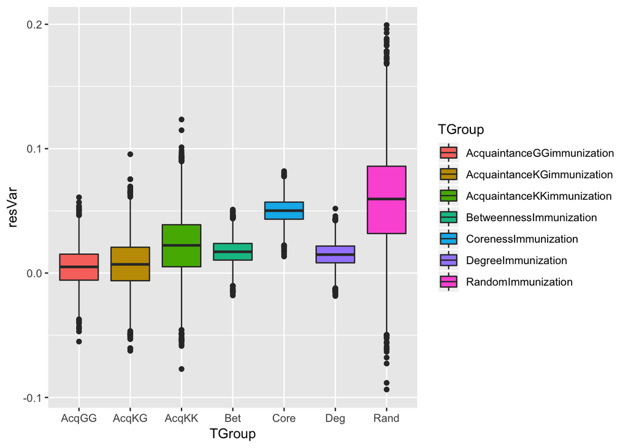

```r
ANOPlot <- ggplot(data=ANOdata,aes(x=TGroup,y=resVar,fill=TGroup)) +
           geom_boxplot()  + scale_x_discrete(labels=c("AcqGG", "AcqKG", "AcqKK", "Bet","Core","Deg","Rand"))
print(ANOPlot)
```

```r
# ggsave(filename="Plot2.pdf",plot=ANOPlot,device="pdf")
#+ theme(text = element_text(size=20), axis.text.x = element_text(angle=90, hjust=1))
```

Results for Cut 1: random variation has a greater effect but p is still unrealistically low. Lets do a smaller sample size

```r
nGroup <- 7 # number of treatment groups
nName <- c("RandomImmunization","BetweennessImmunization", "DegreeImmunization", "CorenessImmunization", "AcquaintanceKKimmunization", "AcquaintanceKGimmunization", "AcquaintanceGGimmunization" ) # names of groups
N <- 2
nSize <- c(N,N,N, N, N, N, N) # number of observations in each group
nMean <- c(0.059,0.017,0.015, 0.05, 0.022, 0.007, 0.005) # mean of each group
nSD <- c(0.04, 0.01,0.01, 0.01, 0.025, 0.02, 0.015) # standard deviation of each group

ID <- 1:(sum(nSize)) # id vector for each row
resVar <- c(rnorm(n=nSize[1],mean=nMean[1],sd=nSD[1]),
            rnorm(n=nSize[2],mean=nMean[2],sd=nSD[2]),
            rnorm(n=nSize[3],mean=nMean[3],sd=nSD[3]),
            rnorm(n=nSize[4],mean=nMean[4],sd=nSD[4]),
            rnorm(n=nSize[5],mean=nMean[5],sd=nSD[5]),
            rnorm(n=nSize[6],mean=nMean[6],sd=nSD[6]),
            rnorm(n=nSize[7],mean=nMean[7],sd=nSD[7]))
TGroup <- rep(nName,nSize)
ANOdata <- data.frame(ID,TGroup,resVar)
str(ANOdata)
```

```
## 'data.frame':    14 obs. of  3 variables:
##  $ ID    : int  1 2 3 4 5 6 7 8 9 10 ...
##  $ TGroup: Factor w/ 7 levels "AcquaintanceGGimmunization",..: 7 7 4 4 6 6 5 5 3 3 ...
##  $ resVar: num  -0.00129 0.00857 0.03214 0.0192 0.01454 ...
```

```r
ANOmodel <- aov(resVar~TGroup,data=ANOdata)
print(ANOmodel)
```

```
## Call:
##    aov(formula = resVar ~ TGroup, data = ANOdata)
##
## Terms:
##                      TGroup   Residuals
## Sum of Squares  0.004879482 0.000451573
## Deg. of Freedom           6           7
##
## Residual standard error: 0.008031842
## Estimated effects may be unbalanced
```

```r
print(summary(ANOmodel))
```

```
##             Df   Sum Sq   Mean Sq F value  Pr(>F)
## TGroup       6 0.004879 0.0008132   12.61 0.00191 **
## Residuals    7 0.000452 0.0000645
## ---
## Signif. codes:  0 '***' 0.001 '**' 0.01 '*' 0.05 '.' 0.1 ' ' 1
```

```r
z <- summary(ANOmodel)
str(z)
```

```
## List of 1
##  $ :Classes 'anova' and 'data.frame':    2 obs. of  5 variables:
##   ..$ Df     : num [1:2] 6 7
##   ..$ Sum Sq : num [1:2] 0.004879 0.000452
##   ..$ Mean Sq: num [1:2] 8.13e-04 6.45e-05
##   ..$ F value: num [1:2] 12.6 NA
##   ..$ Pr(>F) : num [1:2] 0.00191 NA
##  - attr(*, "class")= chr [1:2] "summary.aov" "listof"
```

```r
aggregate(resVar~TGroup,data=ANOdata,FUN=mean)
```

```
##                       TGroup      resVar
## 1 AcquaintanceGGimmunization  0.00131690
## 2 AcquaintanceKGimmunization -0.01045831
## 3 AcquaintanceKKimmunization  0.03565965
## 4    BetweennessImmunization  0.02566915
## 5       CorenessImmunization  0.04588670
## 6         DegreeImmunization  0.01899592
## 7         RandomImmunization  0.00364042
```

```r
unlist(z)
```

```
##          Df1          Df2      Sum Sq1      Sum Sq2     Mean Sq1
## 6.000000e+00 7.000000e+00 4.879482e-03 4.515734e-04 8.132470e-04
##     Mean Sq2     F value1     F value2      Pr(>F)1      Pr(>F)2
## 6.451048e-05 1.260643e+01           NA 1.910572e-03           NA
```

```r
unlist(z)[7]
```

```
## F value1
## 12.60643
```

```r
ANOsum <- list(Fval=unlist(z)[7],probF=unlist(z)[9])
ANOsum
```

```
## $Fval
## F value1
## 12.60643
##
## $probF
##     Pr(>F)1
## 0.001910572
```

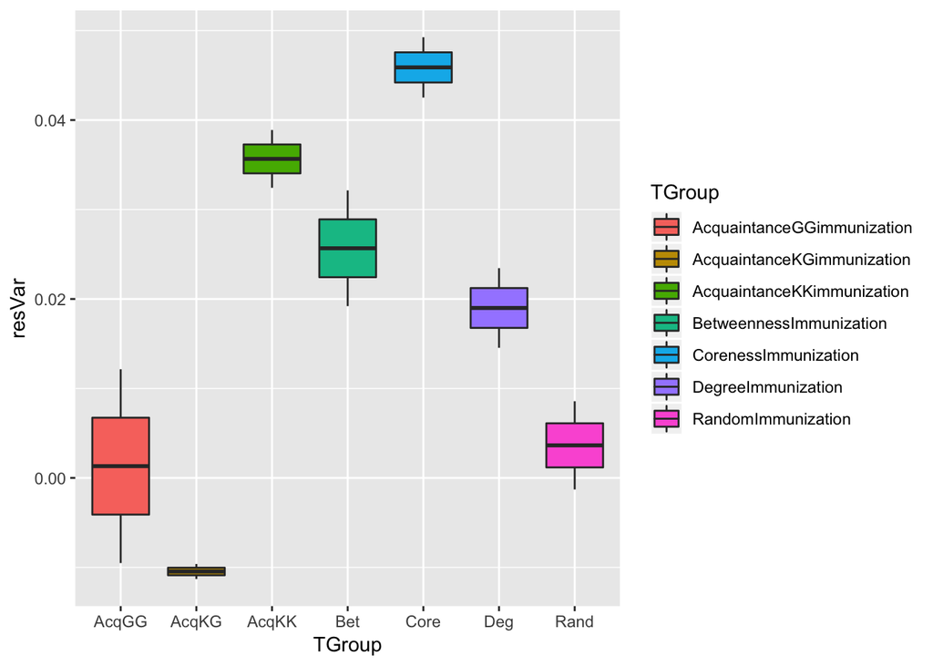

```r
ANOPlot <- ggplot(data=ANOdata,aes(x=TGroup,y=resVar,fill=TGroup)) +
           geom_boxplot()  + scale_x_discrete(labels=c("AcqGG", "AcqKG", "AcqKK", "Bet","Core","Deg","Rand"))
print(ANOPlot)
```

```r
# ggsave(filename="Plot2.pdf",plot=ANOPlot,device="pdf")
#+ theme(text = element_text(size=20), axis.text.x = element_text(angle=90, hjust=1))
```